# Information Gain on Metabolomics

Craig McLean

1/3/2019

# Overview

I need to do some kind of feature selection to find features that are distinctive to each well. I think the play here is to look at information gain.

Information gain is the same parameter used by decision tree models for their feature selection branch points.

```r
omanFT <- read.table(here::here("data/2018-11-23/QA_oman_feature_table.txt"), header = T,
                     stringsAsFactors = F)
dataCols <- 3:7
```

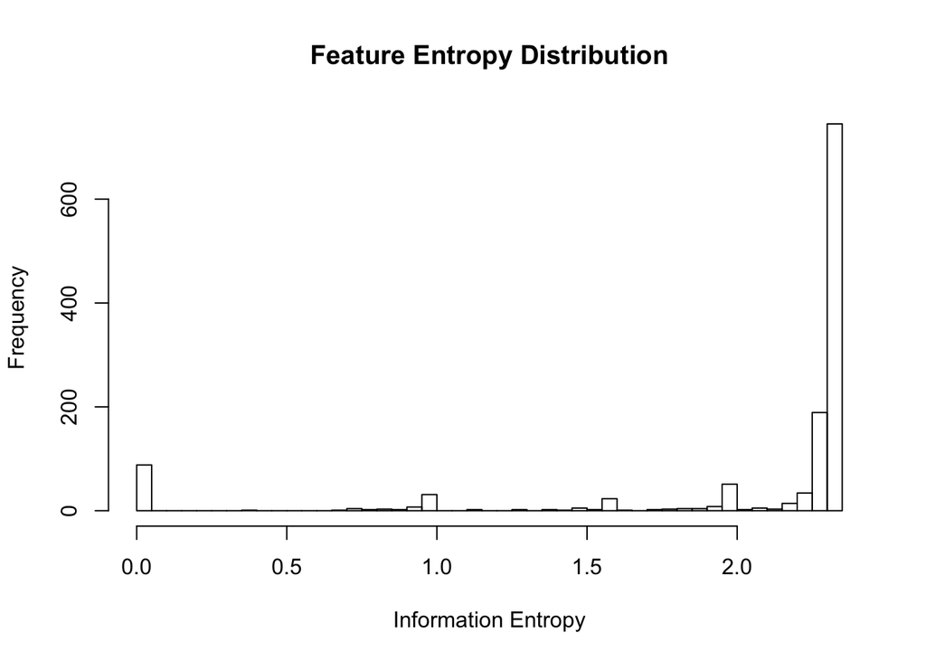

```r
dataMatrix <- omanFT[,grep("\\.", colnames(omanFT))]

dataMatrix <- dataMatrix/rowSums(dataMatrix)

dataMatrix$entropy <- apply(dataMatrix, 1, function(row) {

    if(any(row == 0)) {
        row <- row[row != 0]
    }
    return(-sum(row * log2(row)))

})
hist(dataMatrix$entropy, main = "Feature Entropy Distribution",
     xlab = "Information Entropy",
     breaks = 50)
```

I will use information gain per sample to determine how much each sample contributes towards the data.

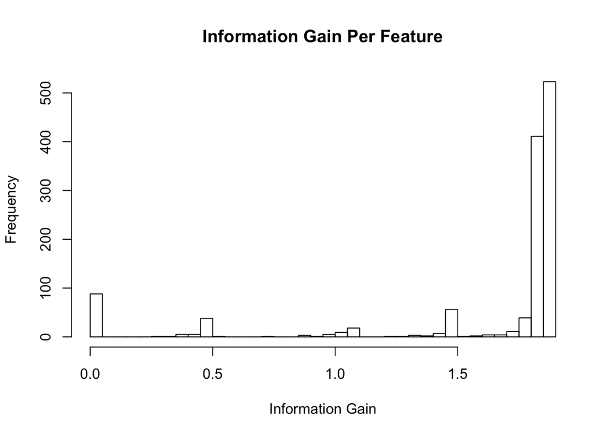

```r
sampleFeatureEntropy <- apply(dataMatrix[,-6], 1, function(row) {
    if(any(row == 0)) {
        row <- row[row > 0]
    }
    p <- row/sum(row)
    return(-p*log2(p))
})

infoGain <- vector(mode = "numeric", length = length(sampleFeatureEntropy))
for(i in seq_along(sampleFeatureEntropy)) {

    curRow <- sampleFeatureEntropy[[i]]

    # case when only one feature makes up the group
    if(dataMatrix$entropy[i] == 0) {
        infoGain[i] <- 0
    } else {
        infoGain[i] <- dataMatrix$entropy[i] - sum(curRow)/length(curRow)
    }
}

infoGain %>% hist(breaks = 30, main = "Information Gain Per Feature",
                  xlab = "Information Gain")
```

I will choose to use .5 as a threshold since it represents only .5 bits of informaiton required to store the different options available.

```r
selectedFeatures <- infoGain <= 0.5
message("Total number of retained features: ", sum(selectedFeatures))
```

```
## Total number of retained features: 138
```

I will assign a feature to a sample by giving it to the sample with the lowest self information.

```r
minEntropyId <- sapply(sampleFeatureEntropy[selectedFeatures], function(groups) {
    names(groups)[which.min(groups)]
})
table(minEntropyId)
```

```
## minEntropyId
## NSHQ.14 WAB.104  WAB.71
##      27       2     109
```

There is an issue here. I cant use the neutral mass column since a good amount of the values were not computed. I need to link this to another column within the original data sheet that contains m/z values. Due to coellution of features I had to go back to the original clean up to accomplish this.

```r
selectedData <- omanFT[selectedFeatures,]
selectedData$classifier <- minEntropyId

compoundDb <- read.csv(here::here("data/2018-11-22/OM17compoundIDs.csv"),
         header = T, skip = 0)

obsFeatures <- paste(signif(compoundDb$m.z),
                     signif(compoundDb$Retention.time..min. * 60), sep = "_")

infoFeatures <- paste(signif(selectedData$mz),
      signif(selectedData$Retention_Time),
      sep = "_")

matchedFeatures <- lapply(infoFeatures, function(curFeat) {
    which(curFeat == obsFeatures)
})

compoundIds <- list()
for(i in seq_along(matchedFeatures)) {

    if(length(matchedFeatures[[i]]) == 0) {
        next
    } else {
        retainRows <- matchedFeatures[[i]]
    }

    compoundIds[[i]] <- compoundDb[retainRows,] %>%
        select(Adducts, Formula, Score, Fragmentation.Score,
               Mass.Error..ppm., Description, m.z, Retention.time..min.) %>%
        mutate(infoRow = i)

}
matchedCompounds <- Reduce(f = rbind, compoundIds)
write.table(x = selectedData, row.names = F,
            file = here("data/2019-01-03/highInfoFeatures.txt"))
write.table(x = matchedCompounds, row.names = F,
            file = here("data/2019-01-03/highInfoCpdMatches.txt"))
```